# climate_ordination

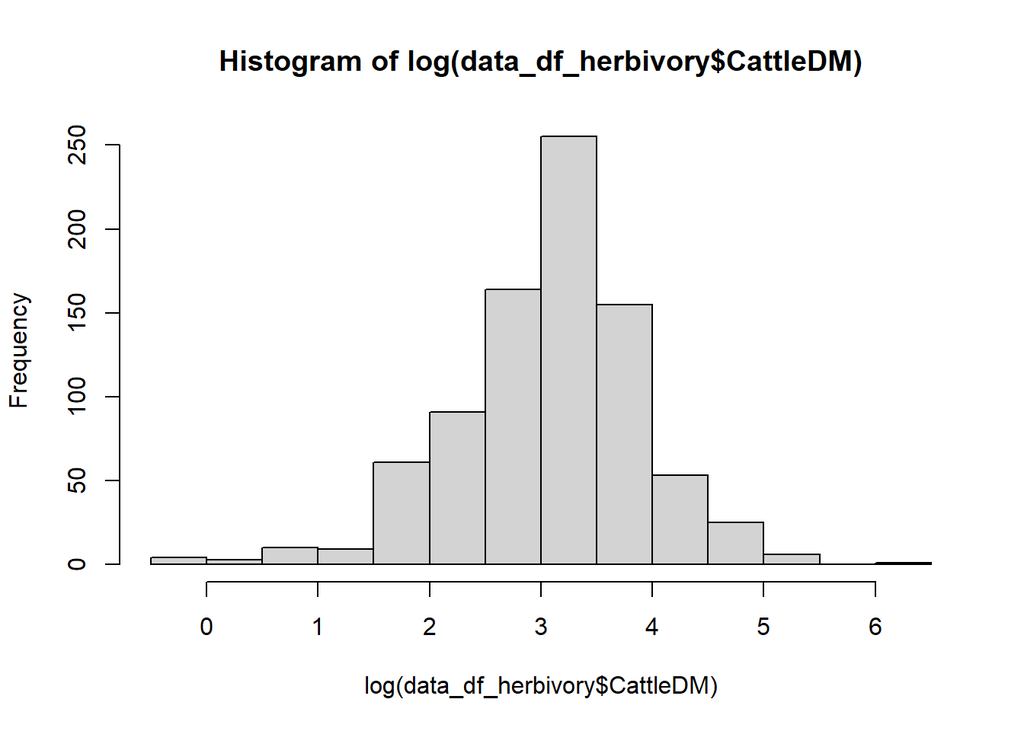

```r
hist(log(data_df_herbivory$CattleDM))
```

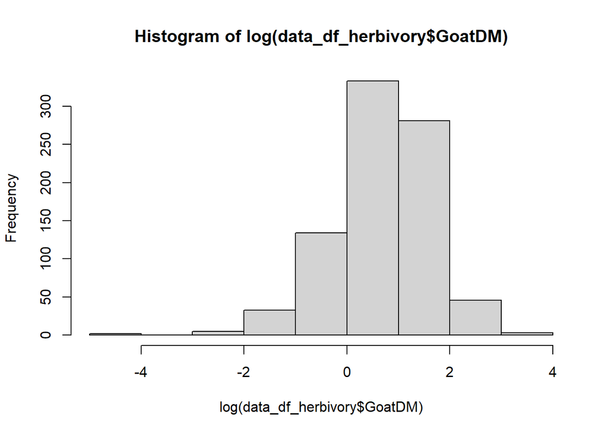

```r
hist(log(data_df_herbivory$GoatDM))
```

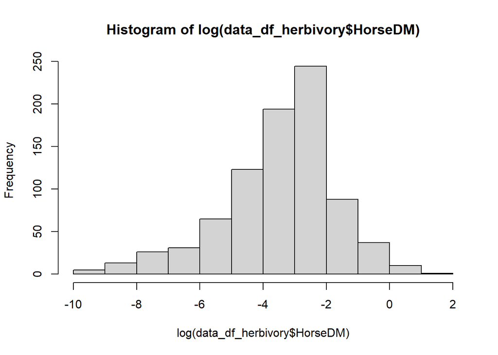

```r
hist(log(data_df_herbivory$HorseDM))
```

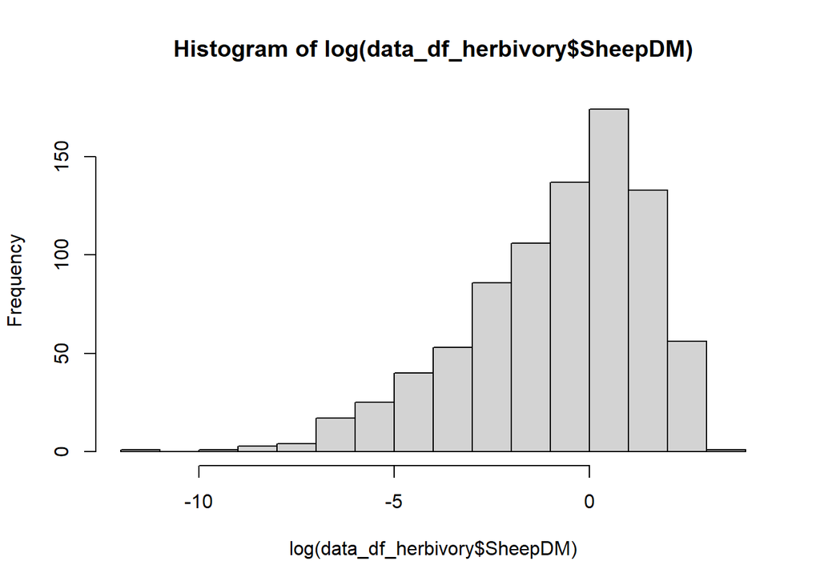

```r
hist(log(data_df_herbivory$SheepDM))
```

```r
####################################Box Cox trial- DO NOT RUN
#dryseasonlength<-data_df_climate$DrySeasonLength
#dryseasonlength<-dryseasonlength[dryseasonlength!=0]

#library(MASS)
#Box<-MASS::boxcox(dryseasonlength~1)
#Cox<- data.frame(Box$x, Box$y)
#Cox2<- Cox[with(Cox, order(-Cox$Box.y)),]
#Cox2[1,]

#lambda<- Cox2[1, "Box.x"]
#T_box<- (dryseasonlength^lambda-1)/lambda

#hist(T_box)

#remove(Box, Cox, Cox2, T_box, lambda)
```

Transforming MCWD and dry season length is difficult and I tried using Boxcox transformations. But I do not understand how I would back transform the values. Also, Boxcox only works for positive numbers, so it would not work for MCWD.

I proceed by only centering and scaling the climate variables (no transformations because I do not undertsnad how I would back transform and interpret the variables)

```r
train <- data_df_climate%>% sample_frac(0.75) #randomly sample 75% of the data to train the model
test <- anti_join(data_df_climate,train)
library(caret)
preproc.param <- train %>%
  caret::preProcess(method = c("center", "scale")) # normalizing/ standardizing the data

train.transformed <- preproc.param %>% predict(train)
test.transformed <- preproc.param %>% predict(test)


modeltrial<- MASS::lda(BinaryBurn~., data=train.transformed)
modeltrial
```

```
## Call:
## lda(BinaryBurn ~ ., data = train.transformed)
##
## Prior probabilities of groups:
##          0          1
## 0.96496815 0.03503185
##
## Group means:
##        Aridity DrySeasonLength DrySeasonRainfall         MAP          MCWD
## 0 -0.006486075      0.01434474       -0.02363362 -0.01834798 -0.0002275873
## 1  0.178661876     -0.39513234        0.65099881  0.50540333  0.0062689961
##          VPD
## 0  0.0231962
## 1 -0.6389500
##
## Coefficients of linear discriminants:
##                          LD1
## Aridity           -1.8420230
## DrySeasonLength   -1.1541377
## DrySeasonRainfall  0.2953691
## MAP                0.6443294
## MCWD               0.1874168
## VPD               -0.5073798
```

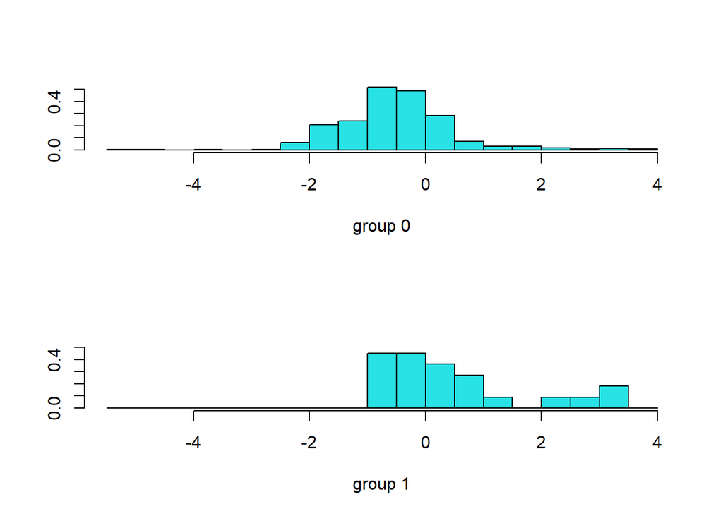

```r
plot(modeltrial)
```

```r
trialpredictions<- modeltrial %>% predict (test.transformed)
names(trialpredictions)
```

```
## [1] "class"     "posterior" "x"
```

```r
x<-table(test.transformed$BinaryBurn, trialpredictions$class)
x #0 were correctly classified?
```

```
##
##       0   1
##   0 201   3
##   1   5   0
```

```r
acc<- (x[1,1]+x[2,2])/(x[1,1]+x[2,1]+x[1,2]+x[2,2])
acc
```

```
## [1] 0.9617225
```

```r
sens<- x[1,1]/(x[1,1]+x[2,1])
sens
```

```
## [1] 0.9757282
```

```r
sp<-1-sens
sp
```

```
## [1] 0.02427184
```

```r
binom <- binom.test(x[1,1], (x[1,1]+x[2,1]), p = acc, alternative = c("greater"), conf.level = 0.95) #not significant significant!
binom
```

```
##
##  Exact binomial test
##
## data:  x[1, 1] and (x[1, 1] + x[2, 1])
## number of successes = 201, number of trials = 206, p-value = 0.1966
## alternative hypothesis: true probability of success is greater than 0.9617225
## 95 percent confidence interval:
##  0.9496463 1.0000000
## sample estimates:
## probability of success
##              0.9757282
```

```r
lda.data.train <- cbind(train.transformed, predict(modeltrial)$x)#################### LD1 for each point in training dataset
lda.data.test <- cbind(test.transformed, trialpredictions$x)

lda.data<- bind_rows(lda.data.train, lda.data.test)


#############################QDA trial
#modeltrial.qda<-MASS::qda(BinaryBurn~., data=train.transformed)
#modeltrial.qda

#trialpredictions.qda<- modeltrial.qda %>% predict(test.transformed)

#x.qda<-table(test.transformed$BinaryBurn, trialpredictions.qda$class)
#x.qda
#acc.qda<- (x.qda[1,1]+x.qda[2,2])/(x.qda[1,1]+x.qda[2,1]+x.qda[1,2]+x.qda[2,2])
#sens.qda<- x.qda[1,1]/(x.qda[1,1]+x.qda[2,1])
#sp.qda<-1-sens.qda
#binom.qda <- binom.test(x.qda[1,1], (x.qda[1,1]+x.qda[2,1]), p = acc, alternative = c("greater"), conf.level = 0.95) #not significant significant!

#remove(modeltrial.qda, trialpredictions.qda, x.qda, acc.qda, sens.qda, sp.qda, binom.qda)

train.herbivory <- data_df_herbivory%>% sample_frac(0.75) #randomly sample 75% of the data to train the model
test.herbivory <- anti_join(data_df_herbivory,train.herbivory)
preproc.param.herbivory <- train.herbivory %>%
  caret::preProcess(method = c("center", "scale")) # normalizing/ standardizing the data

train.herbivory.transformed <- preproc.param.herbivory %>% predict(train.herbivory)
test.herbivory.transformed <- preproc.param.herbivory %>% predict(test.herbivory)

modeltrial.herbivory<- MASS::lda(BinaryBurn~., data=train.herbivory.transformed)
modeltrial.herbivory
```

```
## Call:
## lda(BinaryBurn ~ ., data = train.herbivory.transformed)
##
## Prior probabilities of groups:
##          0          1
## 0.96019108 0.03980892
##
## Group means:
##      BuffaloDM    CattleDM      GoatDM      HorseDM     SheepDM
## 0  0.007287204  0.01123736  0.01678126  0.002320673  0.01688483
## 1 -0.175767363 -0.27104518 -0.40476405 -0.055974625 -0.40726214
##
## Coefficients of linear discriminants:
##                  LD1
## BuffaloDM -0.3523529
## CattleDM  -0.3818732
## GoatDM    -0.4543906
## HorseDM    0.2377667
## SheepDM   -0.6473785
```

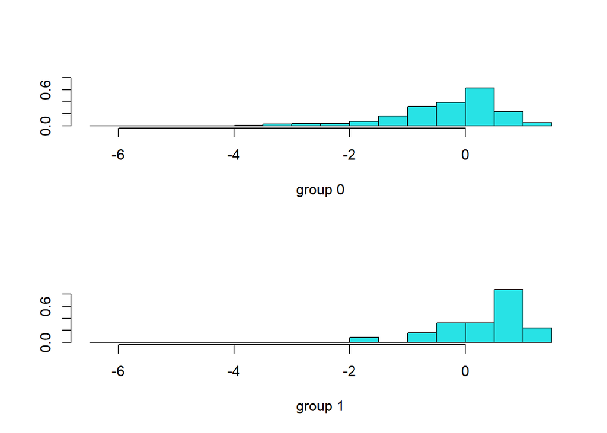

```r
plot(modeltrial.herbivory)
```

```r
trialpredictions.herbivory<- modeltrial.herbivory %>% predict (test.herbivory.transformed)
names(trialpredictions.herbivory)
```

```
## [1] "class"     "posterior" "x"
```

```r
x.herbivory<-table(test.herbivory.transformed$BinaryBurn, trialpredictions.herbivory$class)
x.herbivory #0 were correctly classified?
```

```
##
##       0   1
##   0 170   0
##   1   2   0
```

```r
acc.herbivory<- (x.herbivory[1,1]+x.herbivory[2,2])/(x.herbivory[1,1]+x.herbivory[2,1]+x.herbivory[1,2]+x.herbivory[2,2])
acc.herbivory
```

```
## [1] 0.9883721
```

```r
sens.herbivory<- x.herbivory[1,1]/(x.herbivory[1,1]+x.herbivory[2,1])
sens.herbivory
```

```
## [1] 0.9883721
```

```r
sp.herbivory<-1-sens.herbivory
sp.herbivory
```

```
## [1] 0.01162791
```

```r
binom.herbivory <- binom.test(x.herbivory[1,1], (x.herbivory[1,1]+x.herbivory[2,1]), p = acc.herbivory, alternative = c("greater"), conf.level = 0.95) #not significant!
binom.herbivory
```

```
##
##  Exact binomial test
##
## data:  x.herbivory[1, 1] and (x.herbivory[1, 1] + x.herbivory[2, 1])
## number of successes = 170, number of trials = 172, p-value = 0.6767
## alternative hypothesis: true probability of success is greater than 0.9883721
## 95 percent confidence interval:
##  0.963851 1.000000
## sample estimates:
## probability of success
##              0.9883721
```

```r
lda.data.train.herbivory <- cbind(train.herbivory.transformed, predict(modeltrial.herbivory)$x)#################### LD1 for each point in training dataset
lda.data.test.herbivory <- cbind(test.herbivory.transformed, trialpredictions.herbivory$x)

lda.data.herbivory<- bind_rows(lda.data.train.herbivory, lda.data.test.herbivory)
```

Two options moving ahead, based on Sami’s reply 01/06/2021

1. Use PCA and LDA combination to extract variables of importance that would ultimately be use din the GAM
2. Create new variables, that are combinations of the climate and herbvivory variables (separately), which will be used in the GAM. But interpretability might be hard

For former- (1) For herbivory- seems like either cattle or goat DM can be used and buffalo or sheep DM. (2) For climate- MCWD or dry season rainfall, VPD or dry season length, MAP or or aridity index. [ At this stage I would select MCWD, VPD and MAP]